# Ví dụ về các mô hình phân loại trong thống kê

Dataset: Default – ISLR

Trần Minh Châu

`12/05/2026

# 0. Thư viện

```r
library(ISLR)        # bộ dữ liệu Default
library(dplyr)
library(ggplot2)
library(tidyr)
library(patchwork)
library(scales)
library(corrplot)
library(skimr)
library(MASS)        # lda(), qda()
library(class)       # knn()
library(pROC)        # roc(), auc()
library(broom)       # tidy() cho glm
```

# PHẦN 1 – KHÁM PHÁ DỮ LIỆU (EDA)

# 1. Tổng quan dữ liệu

## 1.1 Đọc & Cấu trúc dữ liệu

```r
df <- Default

# Xem cấu trúc
glimpse(df)
```

```
## Rows: 10,000
## Columns: 4
## $ default <fct> No, No, No, No, No, No, No, No, No, No, No, No, No, No, No, No…
## $ student <fct> No, Yes, No, No, No, Yes, No, Yes, No, No, Yes, Yes, No, No, N…
## $ balance <dbl> 729.5265, 817.1804, 1073.5492, 529.2506, 785.6559, 919.5885, 8…
## $ income  <dbl> 44361.625, 12106.135, 31767.139, 35704.494, 38463.496, 7491.55…
```

```r
cat("Số hàng:", nrow(df), "\n")
```

```
## Số hàng: 10000
```

```r
cat("Số cột :", ncol(df), "\n\n")
```

```
## Số cột : 4
```

```r
cat("Mô tả các biến:\n")
```

```
## Mô tả các biến:
```

```r
cat("  - default : Factor 2 lớp (No / Yes) – biến target\n")
```

```
##   - default : Factor 2 lớp (No / Yes) – biến target
```

```r
cat("  - student : Factor 2 lớp (No / Yes) – có phải sinh viên không\n")
```

```
##   - student : Factor 2 lớp (No / Yes) – có phải sinh viên không
```

```r
cat("  - balance : Số dư trung bình tháng sau khi thanh toán tối thiểu (USD)\n")
```

```
##   - balance : Số dư trung bình tháng sau khi thanh toán tối thiểu (USD)
```

```r
cat("  - income  : Thu nhập hàng năm của khách hàng (USD)\n")
```

```
##   - income  : Thu nhập hàng năm của khách hàng (USD)
```

## 1.2 Thống kê mô tả

```r
skim(df)
```

Data summary

| Name | df |
| --- | --- |
| Number of rows | 10000 |
| Number of columns | 4 |
| _______________________ |  |
| Column type frequency: |  |
| factor | 2 |
| numeric | 2 |
| ________________________ |  |
| Group variables | None |

**Variable type: factor**

| skim_variable | n_missing | complete_rate | ordered | n_unique | top_counts |
| --- | --- | --- | --- | --- | --- |
| default | 0 | 1 | FALSE | 2 | No: 9667, Yes: 333 |
| student | 0 | 1 | FALSE | 2 | No: 7056, Yes: 2944 |

**Variable type: numeric**

| skim_variable | n_missing | complete_rate | mean | sd | p0 | p25 | p50 | p75 | p100 | hist |
| --- | --- | --- | --- | --- | --- | --- | --- | --- | --- | --- |
| balance | 0 | 1 | 835.37 | 483.71 | 0.00 | 481.73 | 823.64 | 1166.31 | 2654.32 | ▆▇▅▁▁ |
| income | 0 | 1 | 33516.98 | 13336.64 | 771.97 | 21340.46 | 34552.64 | 43807.73 | 73554.23 | ▂▇▇▅▁ |

> 📊 Bộ dữ liệu `Default` có 10,000 quan sát, 2 biến định lượng (`balance`, `income`) và 2 biến định tính (`default`, `student`).

# 2. Biến Target (default)

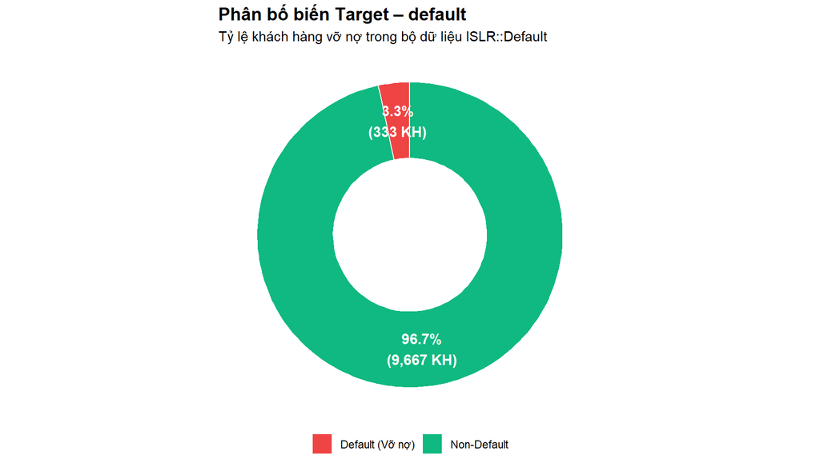

```r
target_summary <- df %>%
  count(default) %>%
  mutate(
    label   = ifelse(default == "Yes", "Default (Vỡ nợ)", "Non-Default"),
    pct     = n / sum(n),
    pct_lab = percent(pct, accuracy = 0.1)
  )

default_pct <- target_summary %>%
  filter(default == "Yes") %>%
  pull(pct_lab)

ggplot(target_summary, aes(x = 2, y = n, fill = label)) +
  geom_col(width = 1, color = "white") +
  coord_polar(theta = "y") +
  xlim(0.5, 2.5) +
  geom_text(
    aes(label = paste0(pct_lab, "\n(", comma(n), " KH)")),
    position = position_stack(vjust = 0.5),
    size = 4, fontface = "bold", color = "white"
  ) +
  annotate("text", x = 0, y = 0,
           label = paste0(default_pct, "\nDefault"),
           size = 6, fontface = "bold") +
  scale_fill_manual(values = c("Default (Vỡ nợ)" = "#ef4444",
                               "Non-Default"      = "#10b981")) +
  labs(
    title    = "Phân bố biến Target – default",
    subtitle = "Tỷ lệ khách hàng vỡ nợ trong bộ dữ liệu ISLR::Default",
    fill     = NULL
  ) +
  theme_void() +
  theme(
    plot.title    = element_text(face = "bold", size = 14),
    plot.subtitle = element_text(size = 11),
    legend.position = "bottom"
  )
```

> ⚠️ Class Imbalance: Tỷ lệ xấp xỉ 97/3 – mất cân bằng lớp rất cao.

# 3. Phân phối biến định lượng

## 3.1 Histogram – balance & income

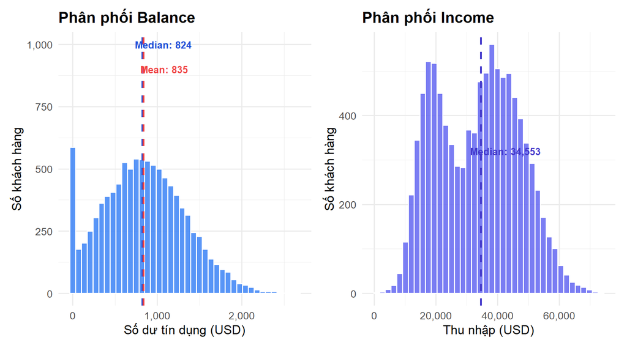

```r
p1 <- ggplot(df, aes(x = balance)) +
  geom_histogram(bins = 40, fill = "#3b82f6", color = "white", alpha = 0.85) +
  geom_vline(xintercept = median(df$balance), color = "#1d4ed8",
             linetype = "dashed", linewidth = 1) +
  geom_vline(xintercept = mean(df$balance), color = "#ef4444",
             linetype = "dashed", linewidth = 1) +
  annotate("text", x = median(df$balance) + 250, y = 1000,
           label = paste0("Median: ", comma(round(median(df$balance)))),
           color = "#1d4ed8", size = 3.5, fontface = "bold") +
  annotate("text", x = mean(df$balance) + 250, y = 900,
           label = paste0("Mean: ", comma(round(mean(df$balance)))),
           color = "#ef4444", size = 3.5, fontface = "bold") +
  scale_x_continuous(labels = comma) +
  scale_y_continuous(labels = comma) +
  labs(title = "Phân phối Balance",
       x = "Số dư tín dụng (USD)", y = "Số khách hàng") +
  theme_minimal(base_size = 13) +
  theme(plot.title = element_text(face = "bold"))

p2 <- ggplot(df, aes(x = income)) +
  geom_histogram(bins = 40, fill = "#6366f1", color = "white", alpha = 0.85) +
  geom_vline(xintercept = median(df$income), color = "#4338ca",
             linetype = "dashed", linewidth = 1) +
  annotate("text", x = median(df$income) + 8000, y = 320,
           label = paste0("Median: ", comma(round(median(df$income)))),
           color = "#4338ca", size = 3.5, fontface = "bold") +
  scale_x_continuous(labels = comma) +
  scale_y_continuous(labels = comma) +
  labs(title = "Phân phối Income",
       x = "Thu nhập (USD)", y = "Số khách hàng") +
  theme_minimal(base_size = 13) +
  theme(plot.title = element_text(face = "bold"))

p1 + p2
```

## 3.2 Boxplot – balance & income theo nhóm Default

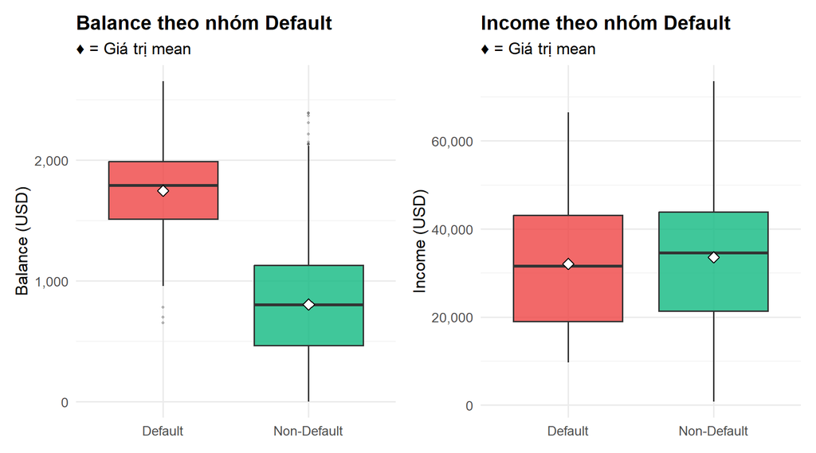

```r
df_lab <- df %>%
  mutate(default_label = ifelse(default == "Yes", "Default", "Non-Default"))

p3 <- ggplot(df_lab, aes(x = default_label, y = balance, fill = default_label)) +
  geom_boxplot(alpha = 0.8, outlier.alpha = 0.3, outlier.size = 0.8) +
  stat_summary(fun = mean, geom = "point", shape = 23, size = 3,
               fill = "white", color = "black") +
  scale_fill_manual(values = c("Default" = "#ef4444", "Non-Default" = "#10b981")) +
  scale_y_continuous(labels = comma) +
  labs(title = "Balance theo nhóm Default",
       subtitle = "♦ = Giá trị mean",
       x = NULL, y = "Balance (USD)", fill = NULL) +
  theme_minimal(base_size = 13) +
  theme(plot.title = element_text(face = "bold"), legend.position = "none")

p4 <- ggplot(df_lab, aes(x = default_label, y = income, fill = default_label)) +
  geom_boxplot(alpha = 0.8, outlier.alpha = 0.3, outlier.size = 0.8) +
  stat_summary(fun = mean, geom = "point", shape = 23, size = 3,
               fill = "white", color = "black") +
  scale_fill_manual(values = c("Default" = "#ef4444", "Non-Default" = "#10b981")) +
  scale_y_continuous(labels = comma) +
  labs(title = "Income theo nhóm Default",
       subtitle = "♦ = Giá trị mean",
       x = NULL, y = "Income (USD)", fill = NULL) +
  theme_minimal(base_size = 13) +
  theme(plot.title = element_text(face = "bold"), legend.position = "none")

p3 + p4
```

> **📌** Nhóm Default có balance trung vị cao hơn rõ rệt so với Non-Default → `balance` là predictor quan trọng. Ngược lại, `income` giữa hai nhóm không chênh lệch nhiều.

# 4. Biến phân loại – student & Default

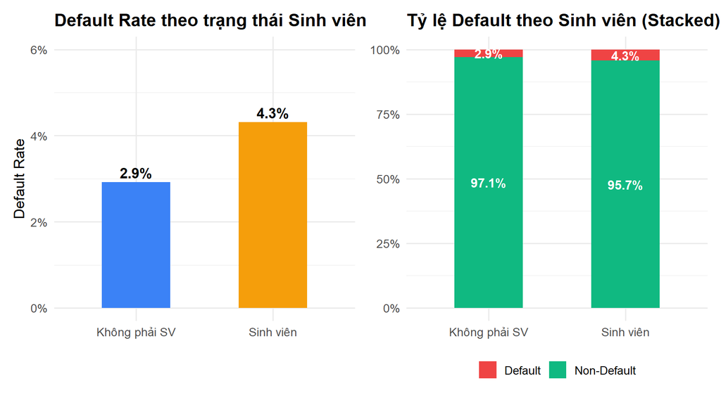

```r
student_rate <- df %>%
  group_by(student) %>%
  summarise(
    n    = n(),
    rate = mean(default == "Yes"),
    .groups = "drop"
  ) %>%
  mutate(label = ifelse(student == "Yes", "Sinh viên", "Không phải SV"),
         pct   = percent(rate, 0.1))

p_student <- ggplot(student_rate, aes(x = label, y = rate, fill = label)) +
  geom_col(width = 0.5, show.legend = FALSE) +
  geom_text(aes(label = pct), vjust = -0.4, fontface = "bold", size = 4.5) +
  scale_fill_manual(values = c("Sinh viên" = "#f59e0b",
                               "Không phải SV" = "#3b82f6")) +
  scale_y_continuous(labels = percent, limits = c(0, 0.06)) +
  labs(title = "Default Rate theo trạng thái Sinh viên",
       x = NULL, y = "Default Rate") +
  theme_minimal(base_size = 13) +
  theme(plot.title = element_text(face = "bold"))

# Stacked bar
p_stack <- df %>%
  count(student, default) %>%
  group_by(student) %>%
  mutate(pct = n / sum(n),
         student_label = ifelse(student == "Yes", "Sinh viên", "Không phải SV"),
         default_label = ifelse(default == "Yes", "Default", "Non-Default")) %>%
  ggplot(aes(x = student_label, y = pct, fill = default_label)) +
  geom_col(width = 0.5) +
  geom_text(aes(label = percent(pct, 0.1)),
            position = position_stack(vjust = 0.5),
            fontface = "bold", color = "white", size = 4) +
  scale_fill_manual(values = c("Default" = "#ef4444", "Non-Default" = "#10b981")) +
  scale_y_continuous(labels = percent) +
  labs(title = "Tỷ lệ Default theo Sinh viên (Stacked)",
       x = NULL, y = NULL, fill = NULL) +
  theme_minimal(base_size = 13) +
  theme(plot.title = element_text(face = "bold"),
        legend.position = "bottom")

p_student + p_stack
```

> **📌** Sinh viên có tỷ lệ default cao hơn (~4.3% vs ~2.9%), tuy nhiên sự chênh lệch không quá lớn. Biến `student` vẫn có thể mang thông tin hữu ích khi kết hợp với `balance`.

# 5. Scatter Plot – balance vs income

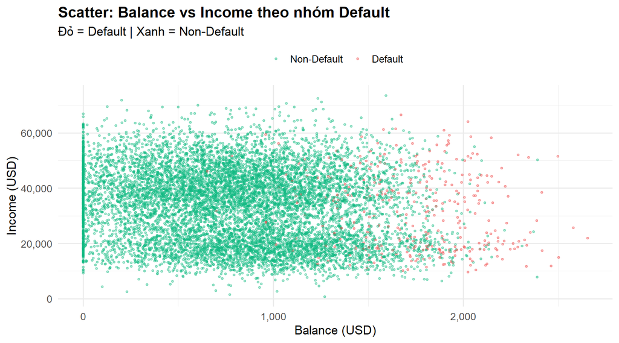

```r
ggplot(df, aes(x = balance, y = income, color = default)) +
  geom_point(alpha = 0.35, size = 0.9) +
  scale_color_manual(
    values = c("No" = "#10b981", "Yes" = "#ef4444"),
    labels = c("Non-Default", "Default")
  ) +
  scale_x_continuous(labels = comma) +
  scale_y_continuous(labels = comma) +
  labs(
    title    = "Scatter: Balance vs Income theo nhóm Default",
    subtitle = "Đỏ = Default | Xanh = Non-Default",
    x = "Balance (USD)", y = "Income (USD)", color = NULL
  ) +
  theme_minimal(base_size = 13) +
  theme(
    plot.title    = element_text(face = "bold"),
    legend.position = "top"
  )
```

> **📌** Khách hàng vỡ nợ (đỏ) tập trung rõ rệt ở vùng balance cao. Biến income không phân tách được hai nhóm, trong khi balance phân tách khá tốt.

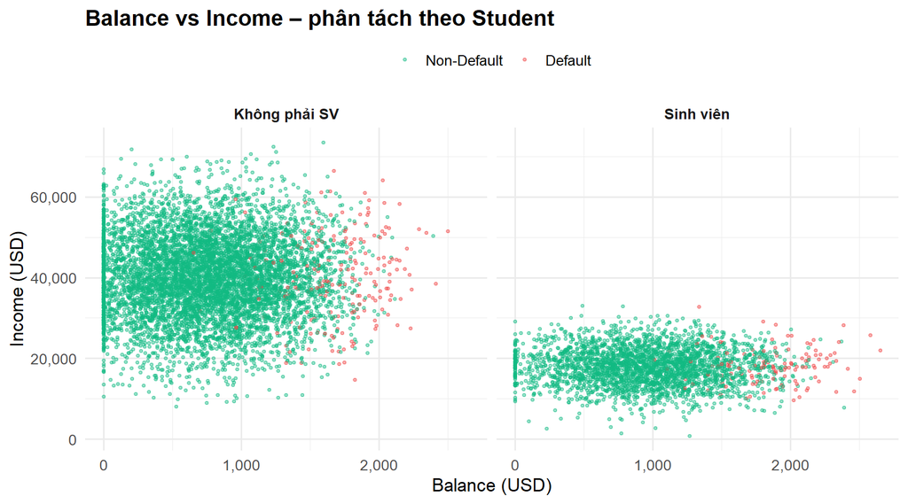

```r
ggplot(df, aes(x = balance, y = income, color = default)) +
  geom_point(alpha = 0.4, size = 0.9) +
  facet_wrap(~student, labeller = labeller(student = c("No" = "Không phải SV",
                                                        "Yes" = "Sinh viên"))) +
  scale_color_manual(
    values = c("No" = "#10b981", "Yes" = "#ef4444"),
    labels = c("Non-Default", "Default")
  ) +
  scale_x_continuous(labels = comma) +
  scale_y_continuous(labels = comma) +
  labs(
    title    = "Balance vs Income – phân tách theo Student",
    x = "Balance (USD)", y = "Income (USD)", color = NULL
  ) +
  theme_minimal(base_size = 13) +
  theme(plot.title = element_text(face = "bold"),
        legend.position = "top",
        strip.text = element_text(face = "bold"))
```

# 6. Ma trận Tương quan

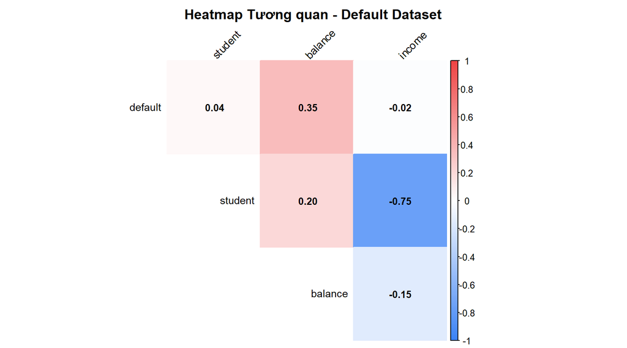

```r
library(dplyr)
library(corrplot)

# Encode factor thành số để tính correlation
df_num <- df %>%
  mutate(
    default_n = as.integer(default == "Yes"),
    student_n = as.integer(student == "Yes")
  ) %>%
  dplyr::select(default_n, student_n, balance, income)

corr_mat <- cor(df_num, use = "complete.obs")

rownames(corr_mat) <- colnames(corr_mat) <- c("default", "student", "balance", "income")

corrplot(
  corr_mat,
  method = "color",
  type = "upper",
  addCoef.col = "black",
  number.cex = 0.85,
  tl.col = "black",
  tl.srt = 45,
  tl.cex = 0.9,
  col = colorRampPalette(c("#3b82f6", "white", "#ef4444"))(200),
  diag = FALSE,
  title = "Heatmap Tương quan - Default Dataset",
  mar = c(0, 0, 2, 0)
)
```

> 📌 Biến balance có tương quan dương rõ nhất với default ($r \approx 0.35$), cho thấy khách hàng có số dư thẻ tín dụng cao hơn thường có xu hướng vỡ nợ cao hơn. Trong khi đó, income có tương quan âm rất nhẹ với default ($r \approx -0.02$), nên mối liên hệ tuyến tính giữa thu nhập và khả năng vỡ nợ là không đáng kể.

# PHẦN 2 – XÂY DỰNG MÔ HÌNH

# Ví dụ 2.3. Logistic Regression

```r
glm.fit <- glm(
  default ~ student + balance + income,
  data = Default,
  family = binomial)
summary(glm.fit)
```

```
##
## Call:
## glm(formula = default ~ student + balance + income, family = binomial,
##     data = Default)
##
## Coefficients:
##               Estimate Std. Error z value Pr(>|z|)
## (Intercept) -1.087e+01  4.923e-01 -22.080  < 2e-16 ***
## studentYes  -6.468e-01  2.363e-01  -2.738  0.00619 **
## balance      5.737e-03  2.319e-04  24.738  < 2e-16 ***
## income       3.033e-06  8.203e-06   0.370  0.71152
## ---
## Signif. codes:  0 '***' 0.001 '**' 0.01 '*' 0.05 '.' 0.1 ' ' 1
##
## (Dispersion parameter for binomial family taken to be 1)
##
##     Null deviance: 2920.6  on 9999  degrees of freedom
## Residual deviance: 1571.5  on 9996  degrees of freedom
## AIC: 1579.5
##
## Number of Fisher Scoring iterations: 8
```

# Ví dụ 2.4. Linear Discriminant Analysis (LDA)

```r
lda.fit <- lda(default ~ student + balance + income, data = Default)
lda.fit
```

```
## Call:
## lda(default ~ student + balance + income, data = Default)
##
## Prior probabilities of groups:
##     No    Yes
## 0.9667 0.0333
##
## Group means:
##     studentYes   balance   income
## No   0.2914037  803.9438 33566.17
## Yes  0.3813814 1747.8217 32089.15
##
## Coefficients of linear discriminants:
##                      LD1
## studentYes -1.746631e-01
## balance     2.243541e-03
## income      3.367310e-06
```

Sau khi ước lượng mô hình LDA, ta xét hai khách hàng mới đều không phải sinh viên,  
có thu nhập bằng mức trung bình mẫu, nhưng có số dư thẻ tín dụng lần lượt là  
1000 và 2000.

```r
new_data <- data.frame(
  student = factor(c("No", "No"), levels = levels(Default$student)),
  balance = c(1000, 2000),
  income = c(mean(Default$income), mean(Default$income))
)

lda.pred <- predict(lda.fit, newdata = new_data)

lda_result <- data.frame(
  balance = new_data$balance,
  income = round(new_data$income, 2),
  student = new_data$student,
  P_No = round(lda.pred$posterior[, "No"], 4),
  P_Yes = round(lda.pred$posterior[, "Yes"], 4),
  Predicted = lda.pred$class
)

lda_result
```

|  | balance | income | student | P_No | P_Yes | Predicted |
| --- | --- | --- | --- | --- | --- | --- |
| 1 | 1000 | 33516.98 | No | 0.9894 | 0.0106 | No |
| 2 | 2000 | 33516.98 | No | 0.4585 | 0.5415 | Yes |

# Ví dụ 2.5. Quadratic Discriminant Analysis (QDA)

```r
qda.fit <- qda(default ~ student + balance + income, data = Default)
qda.fit
```

```
## Call:
## qda(default ~ student + balance + income, data = Default)
##
## Prior probabilities of groups:
##     No    Yes
## 0.9667 0.0333
##
## Group means:
##     studentYes   balance   income
## No   0.2914037  803.9438 33566.17
## Yes  0.3813814 1747.8217 32089.15
```

```r
new_data <- data.frame(
student = factor(c("No", "No"), levels = levels(Default$student)),
balance = c(1000, 2000),
income = c(mean(Default$income), mean(Default$income))
)
qda.pred <- predict(qda.fit, newdata = new_data)
qda_result <- data.frame(
balance = new_data$balance,
income = round(new_data$income, 2),
student = new_data$student,
P_No = round(qda.pred$posterior[, "No"], 4),
P_Yes = round(qda.pred$posterior[, "Yes"], 4),
Predicted = qda.pred$class
)
qda_result
```

|  | balance | income | student | P_No | P_Yes | Predicted |
| --- | --- | --- | --- | --- | --- | --- |
| 1 | 1000 | 33516.98 | No | 0.9941 | 0.0059 | No |
| 2 | 2000 | 33516.98 | No | 0.4681 | 0.5319 | Yes |

> 👉 QDA linh hoạt hơn LDA (dùng ma trận hiệp phương sai riêng cho từng lớp). Có thể cho sensitivity cao hơn nhưng rủi ro overfitting hơn LDA khi dữ liệu nhỏ.

# Ví dụ 2.6. K-Nearest Neighbors (KNN)

> Hàm `knn()` từ package `class` – bắt buộc chuẩn hóa dữ liệu trước khi dùng.

## Chuẩn hóa dữ liệu

```r
data(Default)
set.seed(1)
student_num <- ifelse(Default$student == "Yes", 1, 0)
X <- cbind(
  balance = Default$balance,
  income = Default$income,
  student = student_num
)

X_scaled <- scale(X)

train <- sample(1:nrow(Default), 8000)

train.X <- X_scaled[train, ]
test.X  <- X_scaled[-train, ]

train.default <- Default$default[train]
test.default  <- Default$default[-train]
```

## Dự đoán

```r
set.seed(1)
knn.pred <- knn(train.X, test.X, train.default, k = 5)
table(knn.pred, test.default)
```

```
##         test.default
## knn.pred   No  Yes
##      No  1913   51
##      Yes   17   19
```

```r
mean(knn.pred == test.default)
```

```
## [1] 0.966
```

> 👉 KNN là phương pháp phi tham số, linh hoạt nhưng nhạy cảm với K và cần chuẩn hóa. Kết quả phụ thuộc nhiều vào phân phối dữ liệu cục bộ.